# Read the PACs data from scAPAtrap

Xiaohui Wu, Xingyu Bi, Wenbin Ye

2023-09-20

# Overview

This documentation describes how to use vizAPA to visualize poly(A) sites (pAs) identified from `scAPAtrap`. Here we used scRNA-seq data from peripheral blood mononuclear cells (PBMCs) for demonstration. Please follow the tutorial of [scAPAtrap](https://github.com/BMILAB/scAPAtrap/) first to identify pAs from scRNA-seq. The output of scAPAtrap is an RDA file containing a pA (i.e., peak in scAPAtrap) list with peaks’ meta data and peaks’ count data.

# Load scAPAtrap data

Convert scAPAtrap results into PACdataset object.

```r
library(vizAPA)
library(movAPA)
```

```r
scPACds <- readPACds(pacFile = expma, colDataFile = coldata, noIntergenic = FALSE)
```

## Remove internal priming

```r
library(BSgenome.Hsapiens.NCBI.GRCh38)
bsgenome<-BSgenome.Hsapiens.NCBI.GRCh38
#check the consistency of chromosome names between PACdataset and BSgenome
isChrConsistent(scPACds,bsgenome)
#chromosome names in scPACds@anno$chr should be the same as in bsgenome$seqnames
scPACds@anno$chr<-gsub("chr","",scPACds@anno$chr)
scPACds =removePACdsIP(scPACds , bsgenome, returnBoth=FALSE, up=-140, dn=10, conA=6, sepA=NA,chrCheck = FALSE)
#merge pA sites within 24nt of each other
scPACds=mergePACds_v0(scPACds, d=24)
```

## Read and add the cell type annotation information

```r
filepath<- "./PBMC/scAPAtrap/"

meta<-read.table(paste0(filepath,"scAPAtrap_cell.meta.txt"),sep = "\t",header = TRUE)
row.names(meta)<-meta$barcode

#Check that cells with cell type annotations match those in scPACds@counts
dim(scPACds@counts)
length(intersect(meta$barcode,colnames(scPACds@counts)))

count<- scPACds@counts
row.names(count)<- row.names(scPACds@anno)
count<- count[,intersect(colnames(count),meta$barcode)]
scPACds@counts<- count
scPACds@colData<- subset(scPACds@colData,scPACds@colData$group %in% colnames(count))
loc<- match(scPACds@colData$group,meta$barcode)
scPACds@colData$celltype<-meta$celltype[loc]
```

## Load genome annotation to an annoHub

Load genome annotation from gtf file.

```r
annoSource=new("annoHub")
gff<-useGff("./PBMC/Homo_sapiens.GRCh38.109.gtf.gz")
```

```
## [1] "Extracting UTR region"
```

```r
annoSource=addAnno(annoSource, gff)
```

## Annotation

After read the data into a PACdataset ,we annotate the PACs data using the gtf file(GRCh38). The gene_id is derived from Ensemble. Please make sure the chromosome name of your PACs data is the same as the gtf file.

```r
#check the consistency of chromosome names between PACdataset and genome annotations
isChrConsistent(scPACds,gff)
scPACds<-annotatePAC(scPACds,aGFF=gff)

# extend 3UTR by 1000bp
scPACds=ext3UTRPACds(scPACds, 1000)
save(scPACds,file = "pbmc2_scAPAtrap_APA.rda")
```

The PAC data generated by scAPAtrap can be downloaded by clicking on this link:[pbmc2_scAPAtrap_APA.rda](https://github.com/Bxy237/vizAPA_supplementary.material/tree/master)

```r
load("./PBMC/scAPAtrap/pbmc2_scAPAtrap_APA.rda")
```

Count the number of poly(A) sites in each region of the genome.

```r
table(scPACds@anno$ftr)
```

```
##
##       3UTR       5UTR        CDS       exon intergenic     intron
##       1757          6         36         99       1439       1127
```

Plot the single nucleotide profile of the 3’UTR region to verify that the annotated poly(A) sites are correct.The `movAPA::faFromPACds` will extracts many kinds of sequences from a PACdataset and the `movAPA::plotATCGforFAfile` plots single nucleotide profile using the extracted sequences.

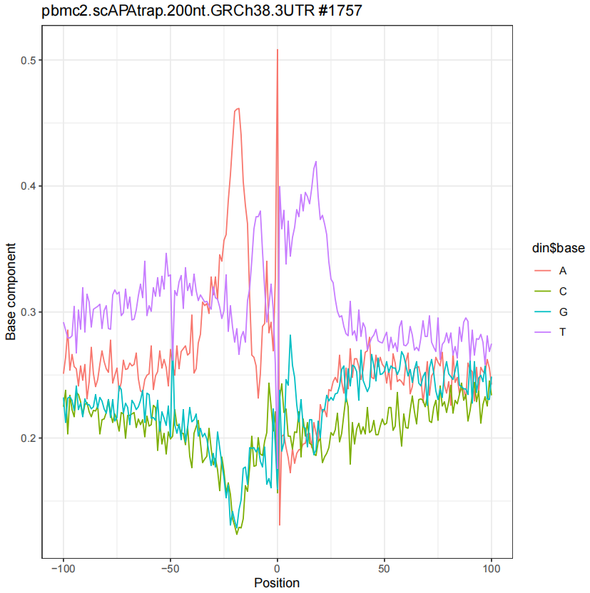

```r
#paramter for what=updn/dn, specifying the upstream/downstream  region from the PAC.
#When up=-100, dn=100, then the output sequence is 201nt
fafiles = faFromPACds(scPACds, bsgenome, what = "updn", fapre = "pbmc2.scAPAtrap.200nt.GRCh38",
                       up = -100, dn = 100, byGrp = "ftr", chrCheck = FALSE)

#Plots single nucleotide profile using the sequences of 3'UTR
plotATCGforFAfile("pbmc2.scAPAtrap.200nt.GRCh38.3UTR.fa", ofreq = FALSE, opdf = TRUE, refPos = 101,
                  filepre = "")
```

# Visualization

## APA expression visualization across cell type

Visualization of average expression levels of all poly(A) sites across cell types.

[figure not shown]

```r
vizStats(scPACds, group='celltype', figType="dot", log=TRUE)+ggplot2::theme(axis.text.x = ggplot2::element_text(angle = 30, hjust = 1))
```

Visualization of the expression levels of poly(A) sites in a given gene across cell types.

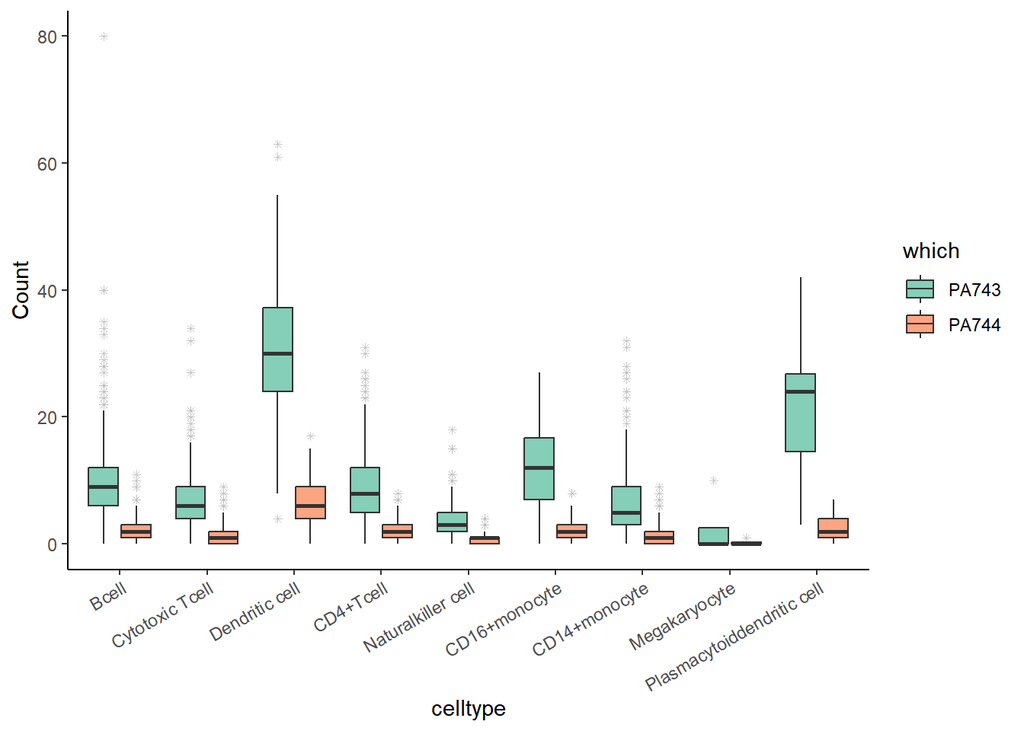

```r
gene="ENST00000307839"
vizStats(scPACds, group='celltype',gene=gene, figType="box")+ggplot2::theme(axis.text.x = ggplot2::element_text(angle = 30, hjust = 1))
```

## Track visualziation

Read BAM files.The BAM files and the corresponding index (.bai) files for the following analysis can be downloaded from the GitHub site of vizAPA: [pbmc2.bam](https://github.com/Bxy237/vizAPA_supplementary.material/tree/master). For demonstration, these BAM files contain only three genes [ENST00000373715, ENST00000307839, ENST00000263379] extracted from the original BAM

```r
bam.files<-c("dedup_pbmc2.forward.sorted_Bcell.mini.sorted.bam",
             "dedup_pbmc2.forward.sorted_CD4+Tcell.mini.sorted.bam",
             "dedup_pbmc2.forward.sorted_CD14+monocyte.mini.sorted.bam",
             "dedup_pbmc2.forward.sorted_CD16+monocyte.mini.sorted.bam",
             "dedup_pbmc2.forward.sorted_CytotoxicTcell.mini.sorted.bam",
             "dedup_pbmc2.forward.sorted_Dendriticcell.mini.sorted.bam",
             "dedup_pbmc2.forward.sorted_Megakaryocyte.mini.sorted.bam",
             "dedup_pbmc2.forward.sorted_Naturalkillercell.mini.sorted.bam",
             "dedup_pbmc2.forward.sorted_Plasmacytoiddendriticcell.mini.sorted.bam")
bam.path<-"./PBMC/pbmc2.bam/"
bam.labels<-c("Bcell","CD4+Tcell","CD14+monocyte","CD16+monocyte",
              "CytotoxicTcell","Dendriticcell","Megakaryocyte","Naturalkillercell","Plasmacytoiddendriticcell")
bam.groups<-c("Bcell","CD4+Tcell","CD14+monocyte","CD16+monocyte",
              "CytotoxicTcell","Dendriticcell","Megakaryocyte","Naturalkillercell","Plasmacytoiddendriticcell")
bams<-readBAMFileNames(bam.files=bam.files, bam.path=bam.path, bam.labels = bam.labels, bam.groups = bam.groups)
```

We selected example genes that have 3’UTR APA sites and plot top poly(A) sites with the most read number.

```r
APAds=get3UTRAPAds(scPACds)
top10=APAds@anno[order(Matrix::rowSums(APAds@counts), decreasing = TRUE)[1:10],]
head(top10[1:5,c(1:6,13)])
```

```
##        chr strand    coord tottag UPA_start  UPA_end            gene
## PA846    3      - 12835986  58468  12835986 12835986 ENST00000396957
## PA487    2      + 84906679  41103  84906679 84906679 ENST00000233143
## PA743    3      + 23919797  28488  23919797 23919797 ENST00000307839
## PA3452  17      + 41691019   9527  41691019 41691019 ENST00000469257
## PA744    3      + 23920910   5472  23920910 23920910 ENST00000307839
```

```r
gene=top10$gene[8]
gene
```

```
## [1] "ENST00000373715"
```

```r
#check the consistency of chromosome names among PACdataset, BAM files, and genome annotations.
isChrConsistent( scPACds,bams, annoSource["gff"],exact=FALSE)
```

```
## [1] TRUE
```

```r
# We can also get full chromosome names of each object.
getChrs(annoSource, which='gff')
```

```
##  [1] "1"          "2"          "3"          "4"          "5"
##  [6] "6"          "7"          "X"          "8"          "9"
## [11] "11"         "10"         "12"         "13"         "14"
## [16] "15"         "16"         "17"         "18"         "20"
## [21] "19"         "Y"          "22"         "21"         "MT"
## [26] "KI270728.1" "KI270727.1" "KI270442.1" "GL000225.1" "GL000009.2"
## [31] "GL000194.1" "GL000205.2" "GL000195.1" "KI270733.1" "GL000219.1"
## [36] "GL000216.2" "KI270744.1" "KI270734.1" "GL000213.1" "GL000220.1"
## [41] "GL000218.1" "KI270731.1" "KI270750.1" "KI270721.1" "KI270726.1"
## [46] "KI270711.1" "KI270713.1"
```

```r
getChrs(bams)
```

```
##   [1] "1"          "10"         "11"         "12"         "13"
##   [6] "14"         "15"         "16"         "17"         "18"
##  [11] "19"         "2"          "20"         "21"         "22"
##  [16] "3"          "4"          "5"          "6"          "7"
##  [21] "8"          "9"          "MT"         "X"          "Y"
##  [26] "KI270728.1" "KI270727.1" "KI270442.1" "KI270729.1" "GL000225.1"
##  [31] "KI270743.1" "GL000008.2" "GL000009.2" "KI270747.1" "KI270722.1"
##  [36] "GL000194.1" "KI270742.1" "GL000205.2" "GL000195.1" "KI270736.1"
##  [41] "KI270733.1" "GL000224.1" "GL000219.1" "KI270719.1" "GL000216.2"
##  [46] "KI270712.1" "KI270706.1" "KI270725.1" "KI270744.1" "KI270734.1"
##  [51] "GL000213.1" "GL000220.1" "KI270715.1" "GL000218.1" "KI270749.1"
##  [56] "KI270741.1" "GL000221.1" "KI270716.1" "KI270731.1" "KI270751.1"
##  [61] "KI270750.1" "KI270519.1" "GL000214.1" "KI270708.1" "KI270730.1"
##  [66] "KI270438.1" "KI270737.1" "KI270721.1" "KI270738.1" "KI270748.1"
##  [71] "KI270435.1" "GL000208.1" "KI270538.1" "KI270756.1" "KI270739.1"
```

[output cut: 24 more lines]

Plot the gene model tracks and the pA Tracks to show the position and the total expression of pAs, separately.Here we extend the gene model by 1000 bp at both ends.

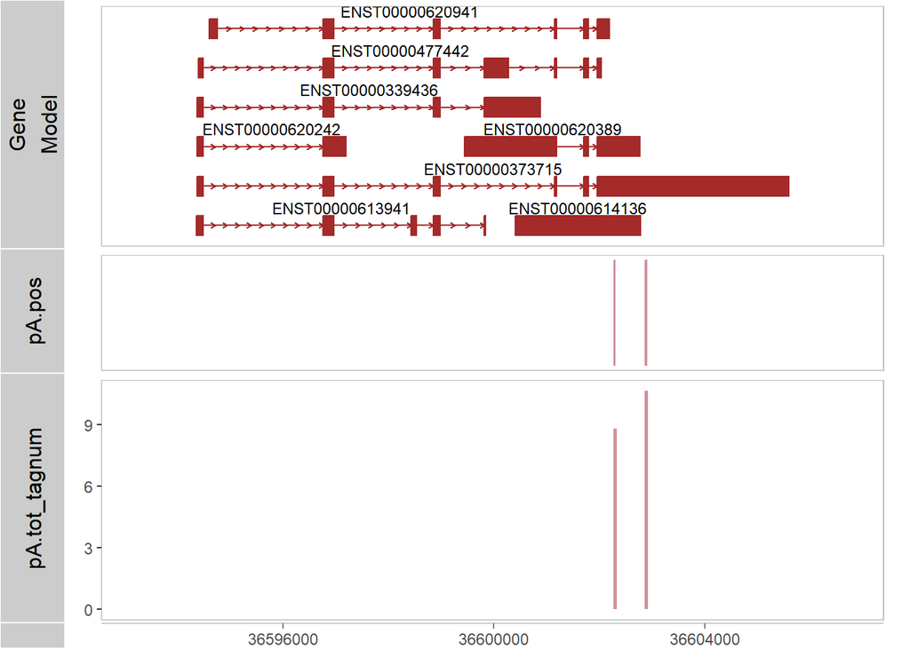

```r
##Here we add a tot_tagnum to the PACds@anno and do log-transformation to show the tot_tagnum clearly.
scPACds@anno$tot_tagnum=Matrix::rowSums(scPACds@counts)
scPACds@anno$tot_tagnum=log2(scPACds@anno$tot_tagnum+1)

vizTracks(gene =gene,
          PACds.list=list(pA=scPACds),
          PA.show=c("pos", "tot_tagnum"),
          annoSource=annoSource,
          PA.columns="coord", PA.width=10, logPA=TRUE,
          space5=1000, space3=1000)
```

Plot an example gene, with gene model, pA coordinates, and BAM coverages.

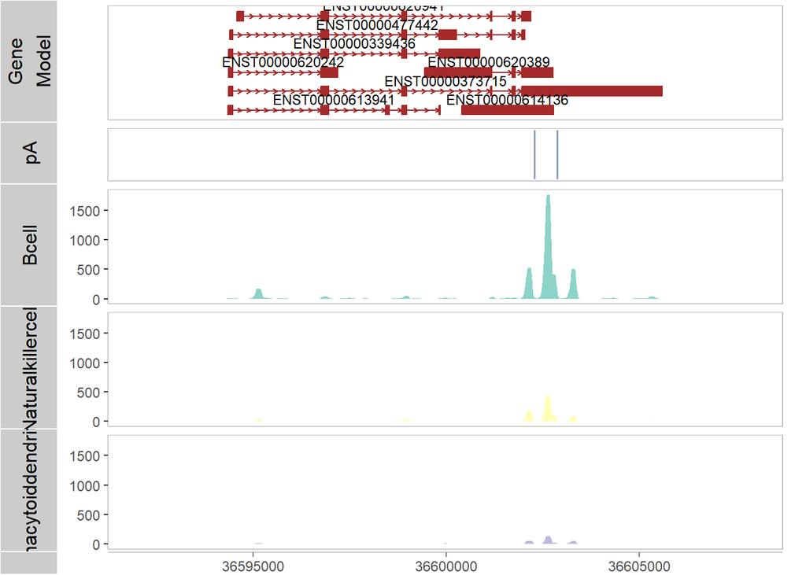

```r
#Due to the large number of cell types, we can choose a few of them to plot the bam coverage.
vizTheme=list(PA.col="#8d9fbb",PA.fill="#8d9fbb",bams.col=c("#8DD3C7","#FFFFB3","#BEBADA"),bams.fill=c("#8DD3C7","#FFFFB3","#BEBADA"))
vizTracks(gene=gene,
           bams=bams[c(1,8,9),], PACds.list=list(pA=scPACds), PA.show=c("pos"),
           annoSource=annoSource,
           PA.columns="coord", PA.width=10,
           space5=1000, space3=1000,vizTheme =vizTheme )
```

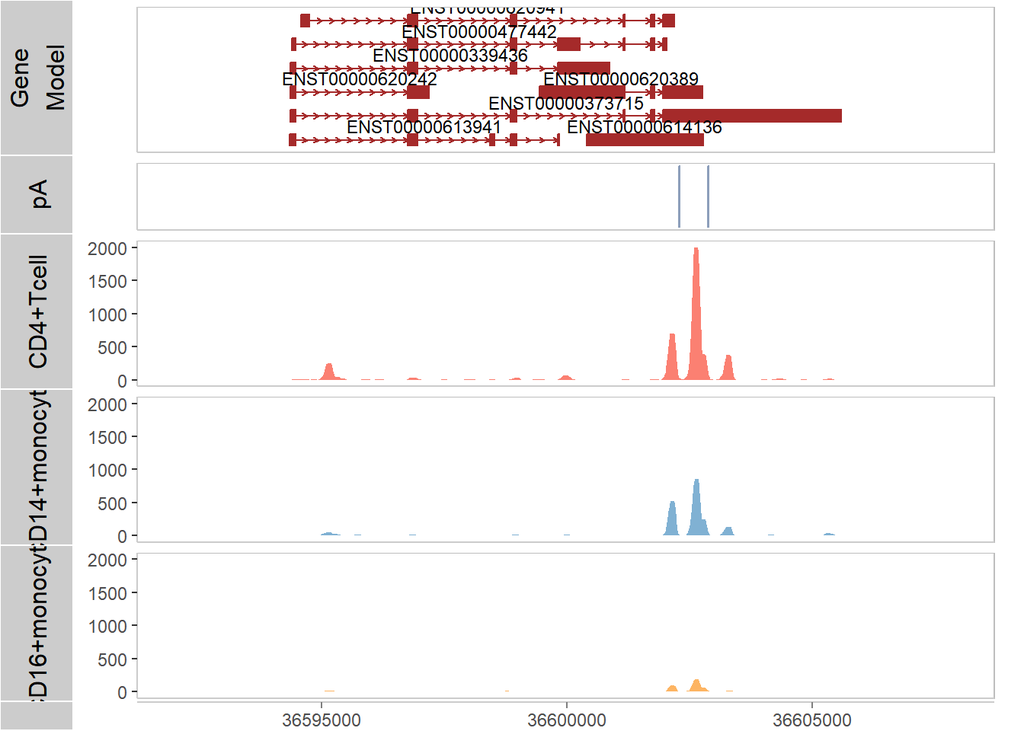

```r
vizTheme=list(PA.col="#8d9fbb",PA.fill="#8d9fbb",bams.col=c("#FB8072","#80B1D3","#FDB462"),bams.fill=c("#FB8072","#80B1D3","#FDB462"))
vizTracks(gene=gene,
           bams=bams[c(2,3,4),], PACds.list=list(pA=scPACds), PA.show=c("pos"),
           annoSource=annoSource,
           PA.columns="coord", PA.width=10,
           space5=1000, space3=1000,vizTheme =vizTheme )
```

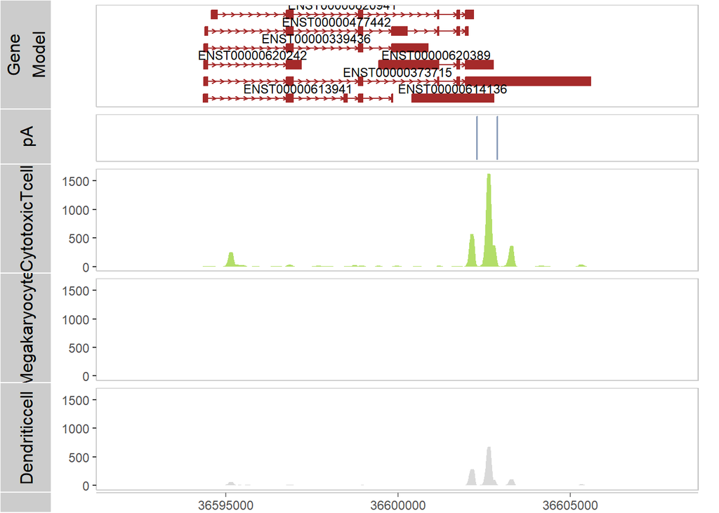

```r
vizTheme=list(PA.col="#8d9fbb",PA.fill="#8d9fbb",bams.col=c("#B3DE69","#FCCDE5","#D9D9D9"),bams.fill=c("#B3DE69","#FCCDE5","#D9D9D9"))
vizTracks(gene=gene,
           bams=bams[c(5,7,6),], PACds.list=list(pA=scPACds), PA.show=c("pos"),
           annoSource=annoSource,
           PA.columns="coord", PA.width=10,
           space5=1000, space3=1000,vizTheme =vizTheme )
```

Plot the pA expression in individual cell.

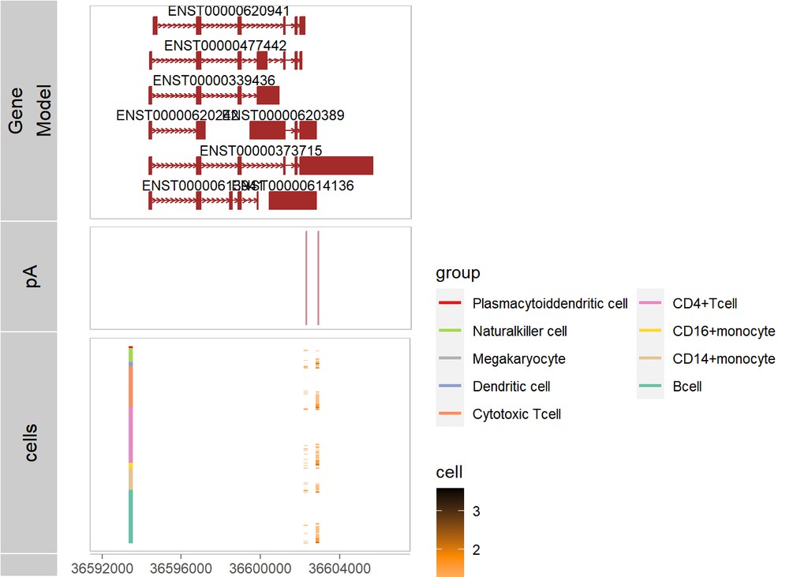

```r
vizTracks(gene=gene,
          PACds.list=list(pA=scPACds), PA.show=c("pos"),
          cells=TRUE, cells.group='celltype',
          cells.method=c('sum'), cells.sort=c('group'),
          cells.width=100,
          annoSource=annoSource,
          PA.columns="coord", PA.width=10, logPA=TRUE,
          space5=1000, space3=1000,
          )  +ggplot2::guides(color=ggplot2::guide_legend(ncol = 2,
                            byrow = F,
                            reverse = T))
```